# Black Zen: A descriptive exploration of meditation in African-Americans

Nicolas Seranio

### Overview

The goal of my project is the describe and characterize the health behaviors of African Americans who practice meditation. I am utilizing the 2017 National Health Interview Survey (NHIS) data.

Faculty/Staff: Gary Kao (Radiation Oncology): Helped me in defining my problem and the health implications I should look into. Sumedha Chhatre (Psychology): Taught me about the wealth of available databases and how to perform my initial analysis. Megan Blanchard (Sociology): Taught me about social considerations when comparing behaviors in groups. Helped with data cleaning.

https://github.com/nseranio/BMIN503_Final_Project

### Introduction

Meditation has been shown to be associated with alterations in brain structure, better mental health, improved attention, greater emotional self-regulation, slower cellular aging, better academic performance, and other outcomes. However, there are very few studies characterizing the prevalence and patterns of use of meditation in the general US adult population. I wanted to explore the role that meditation plays in African-Americans in dealing with their uniqe health and mental health burdens.

My problem is interdisciplinary because it relies on a blend of medicine, sociology, and psychology to grasp the full picture. From working with the faculty and staff they informed me on things that I might need to take into consider in my analysis such as the role of privilege in the form of education and wealth might have one one’s health.

### Methods

The data I used was the “Sample Adult Component” and the “Family Component” of the 2017 NHIS. The data was downloaded from https://www.cdc.gov/nchs/nhis/nhis_2017_data_release.htm. I only kept the respondents who were identified as African-American and then merged the two datasets into a single one. I then divided them into “Meditators” and “Non-meditators” before performing my analyses.

```r
#Load the relevant R packages
library(dplyr)
library(data.table)
#Load in the "Sample Adult" NHIS data.
nhisadult <- read.csv(file = "/Users/Nseranio/Documents/MTR/BMIN\ 503/BMIN503_Final_Project/samadult.csv", header = TRUE, sep = ",")

#Load in the "Family" NHIS data.
nhisfam <- read.csv(file = "/Users/Nseranio/Documents/MTR/BMIN\ 503/BMIN503_Final_Project/familyxx.csv", header = TRUE, sep = ",")

#Delete variables not relevant to project from "Sample Adult" data.
setDT(nhisadult)[, c(4,5,8:10,12,14:16,18:27,29:35,37:43,46,48:50,53:85,87:118,125,127:326,328:361,363:397,399:432,434:484,486,492:496,502,504:510,518,531:534,563:568,571,583:586,595:619,623:629,638,639,644:648,671,672) := NULL]

#Delete variables not relevant to project from "Sample Adult" data.
setDT(nhisfam)[, c(1:5,7:19,21:71,78:127) := NULL]

#Create data with only African-American respondents
nhisafam <- nhisadult[RACERPI2 == 2]

#Merge nhisafam with nhisfam and remove any duplicated rows.
nhismerged <- merge(nhisafam, nhisfam, by = "HHX")
nhismerged <- nhismerged[!duplicated(nhismerged$HHX),]

#Convert NAs to 0s in yoga columns
nhismerged$YTQ_MDY1[is.na(nhismerged$YTQ_MDY1)] <- 0
nhismerged$YTQ_MDT1[is.na(nhismerged$YTQ_MDT1)] <- 0
nhismerged$YTQ_MDQ1[is.na(nhismerged$YTQ_MDQ1)] <- 0

#Create a column of "Meditators" and "Non-meditators"
nhismerged <- nhismerged %>%
  mutate(meditate = ifelse(MBO_MAN1 == 1 |
                           MBO_MND1 == 1 |
                           MBO_SPR1 == 1 |
                           YTQ_MDY1 == 1 |
                           YTQ_MDT1 == 1 |
                           YTQ_MDQ1 == 1, 1, 0))
table(nhismerged$meditate, useNA = "always")
```

```
##
##    0    1 <NA>
## 2475  485    0
```

```r
#Change labels for sex variable
nhismerged$SEX <- factor(nhismerged$SEX, labels=c("Male","Female"))

#Change labels for the meditation variable
nhismerged$meditate <- factor(nhismerged$meditate, labels=c("Non-meditator","Meditator"))

#Change labels for region variable
nhismerged$REGION <- factor(nhismerged$REGION, labels=c("Northeast","Midwest","South","West"))

#Change levels for Depression variable
nhismerged$ASISAD <- factor(nhismerged$ASISAD)
levels(nhismerged$ASISAD) <- list(All="1",Most="2",Some="3",Little="4",None="5")

#Change levels for the naturopathy variable
nhismerged$NAT_USM1 <- factor(nhismerged$NAT_USM1)
levels(nhismerged$NAT_USM1) <- list(Yes="1",No="2")

#Change levels for "Feelings interfered w/ life, past 30 days" variable
nhismerged$ASIMUCH <- factor(nhismerged$ASIMUCH)
levels(nhismerged$ASIMUCH) <- list(Alot="1",Some="2",Alittle="3",Notatall="4")

#Change levels for frequency of vigorous activity variable
nhismerged$VIGFREQW <- factor(nhismerged$VIGFREQW)
levels(nhismerged$VIGFREQW) <- list(Lessthanonceperweek="1",OnetoTwoEight="2", Never="3")

#Change levels for family education variable
nhismerged$FM_EDUC1 <- factor(nhismerged$FM_EDUC1)
levels(nhismerged$FM_EDUC1) <- list(UnderEighth="1",NinetoTwelve="2",GED="3",HSgrad="4", SomeCollege="5",AAvocational="6",AAacademic="7",Bachelors="8",Professional="9")

#Change levels for income group variable
nhismerged$INCGRP5 <- factor(nhismerged$INCGRP5)
levels(nhismerged$INCGRP5) <- list(ZeroTo35k="1",ThirtyFiveto75k="2",SeventyFiveto100k="3",Over100k="4")

#Change levels for SNAP/foodstamps variable
nhismerged$FSNAP <- factor(nhismerged$FSNAP)
levels(nhismerged$FSNAP) <- list(Yes="1",No="2")

#Change levels for the smoking status variable
nhismerged$SMKSTAT2 <- factor(nhismerged$SMKSTAT2)
levels(nhismerged$SMKSTAT2) <- list(CurrEveryday="1",CurrSomeday="2", Former="3", Never="4")

#Creat a dataframe with the different forms of meditation.
MeditationTypes <- c("Mantra","Mindfulness","Spiritual","Yoga","Tai Chi","Qi Gong")
Frequencies <- c(61,81,358,159,18,10)
meditatorgraph <- data.frame(MeditationTypes,Frequencies)
```

### Results

First I wanted to get a better understand of who the people were that identified as “Meditators” and how they compared to African-Americans who didn’t meditate. From the data below it became clear that “Meditators” tend to be a relatively privilged group with higher income, higher income, and less utilization of public services like food stamps.

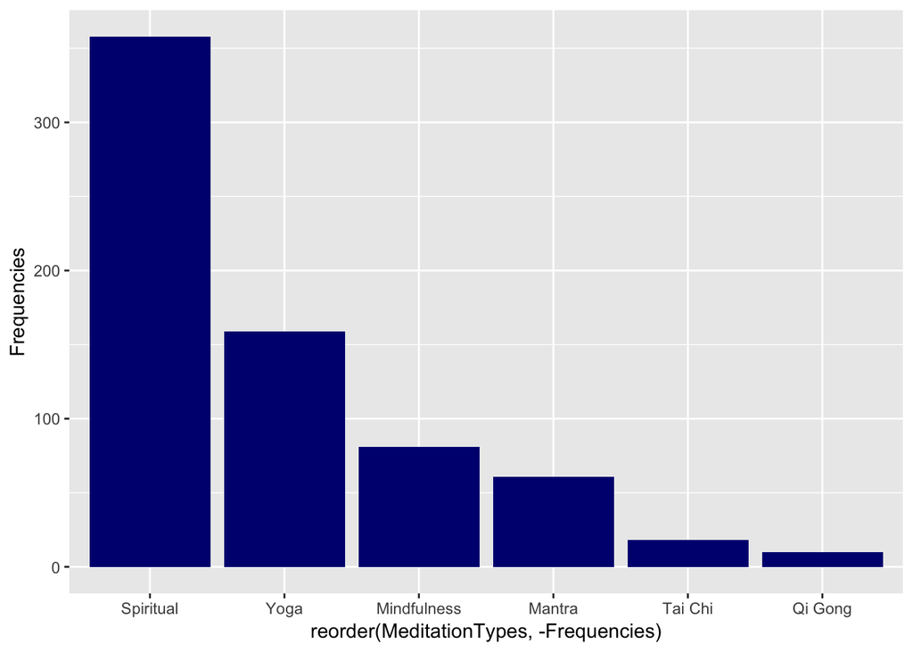

```r
#Load the relevant packages
library(ggplot2)
library(foreign)
library(ggplot2)
library(MASS)
library(Hmisc)
library(reshape2)
#Generate a graph that shows the breakdown of the type of Meditation utilized.
ggplot(data=meditatorgraph, aes(x=reorder(MeditationTypes,-Frequencies), y=Frequencies)) +
  geom_bar(stat="identity", fill="navy")
```

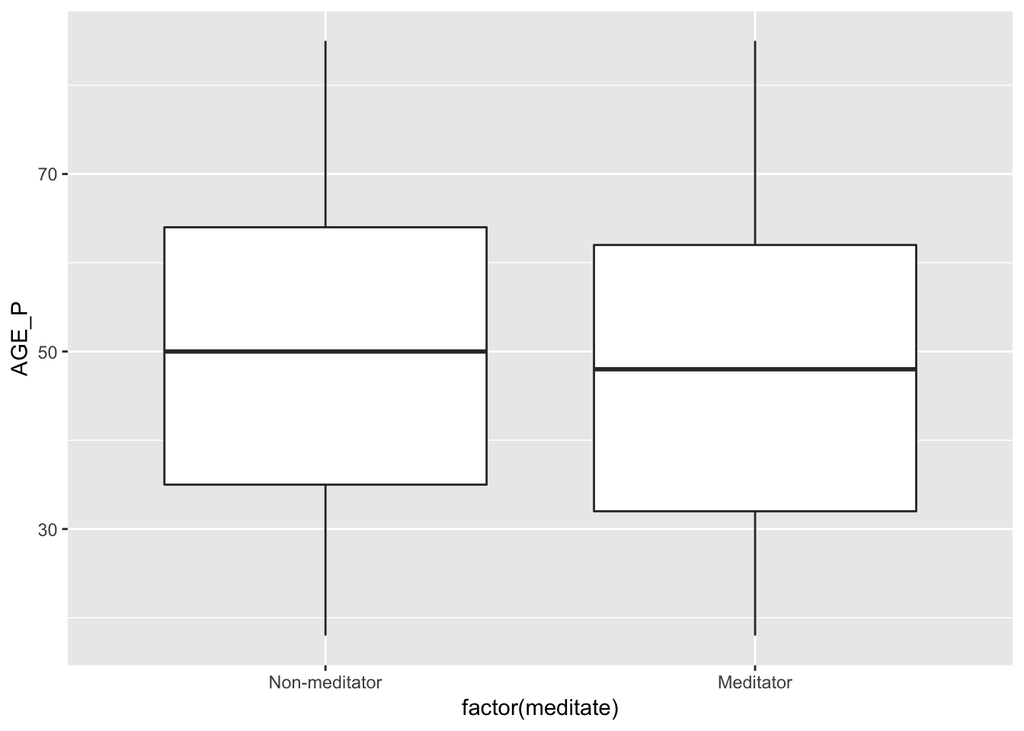

```r
#Generate a graph of the ages of the two groups.
ggplot(data=nhismerged, aes(x=factor(meditate), y=AGE_P)) +
    geom_boxplot()
```

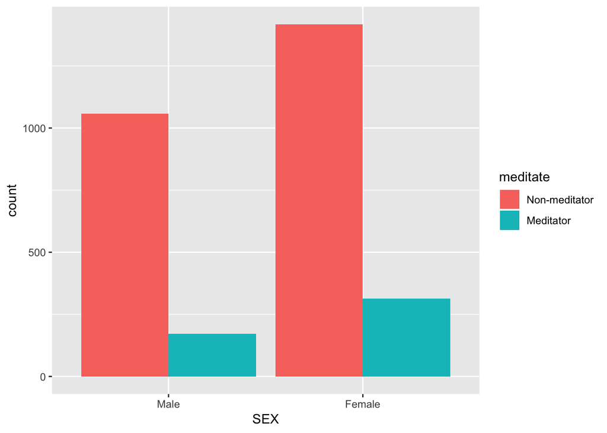

```r
#Generate a graph of the sex of the two groups.
ggplot(data=nhismerged, aes(x=SEX, fill=meditate)) +
    geom_bar(position="dodge")
```

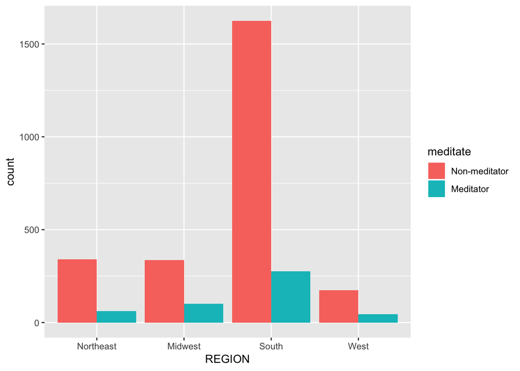

```r
#Generate a graph of the region breakdown of the two groups.
ggplot(data=nhismerged, aes(x=REGION, fill=meditate)) +
    geom_bar(position="dodge")
```

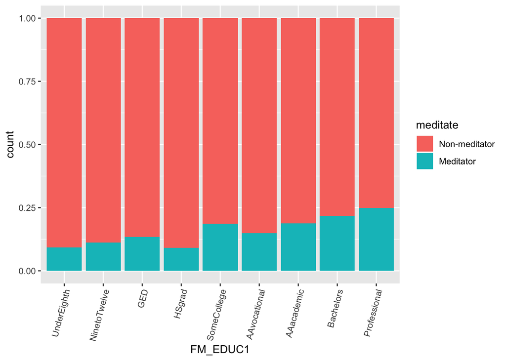

```r
#Generate a graph of the family education of the two groups. Then perform an ordered logistic regression.
ggplot(data=subset(nhismerged, !is.na(FM_EDUC1)), aes(x=FM_EDUC1, fill=meditate)) +
    geom_bar(position="fill") + theme(axis.text.x = element_text(angle = 75, hjust = 1))
```

```r
fmeord <- polr(FM_EDUC1 ~ meditate, data = nhismerged, Hess=TRUE)
summary(fmeord)
```

```
## Call:
## polr(formula = FM_EDUC1 ~ meditate, data = nhismerged, Hess = TRUE)
##
## Coefficients:
##                    Value Std. Error t value
## meditateMeditator 0.6381    0.08784   7.264
##
## Intercepts:
##                          Value    Std. Error t value
## UnderEighth|NinetoTwelve  -3.7113   0.1259   -29.4774
## NinetoTwelve|GED          -1.8351   0.0563   -32.5881
## GED|HSgrad                -1.6444   0.0528   -31.1654
## HSgrad|SomeCollege        -0.4511   0.0405   -11.1328
## SomeCollege|AAvocational   0.4616   0.0406    11.3725
## AAvocational|AAacademic    0.8292   0.0426    19.4757
## AAacademic|Bachelors       1.0364   0.0442    23.4296
## Bachelors|Professional     2.1720   0.0610    35.6146
##
## Residual Deviance: 11544.07
## AIC: 11562.07
## (12 observations deleted due to missingness)
```

```r
ctable3 <- coef(summary(fmeord))
fmeord <- pnorm(abs(ctable3[, "t value"]), lower.tail = FALSE) * 2
ctable3 <- cbind(ctable3, "p value" = fmeord)
ctable3
```

```
##                               Value Std. Error    t value       p value
## meditateMeditator         0.6380596 0.08784209   7.263711  3.766127e-13
## UnderEighth|NinetoTwelve -3.7112543 0.12590188 -29.477355 5.617940e-191
## NinetoTwelve|GED         -1.8350901 0.05631160 -32.588138 6.039340e-233
## GED|HSgrad               -1.6443945 0.05276340 -31.165438 3.133729e-213
## HSgrad|SomeCollege       -0.4511437 0.04052392 -11.132775  8.688753e-29
## SomeCollege|AAvocational  0.4615703 0.04058649  11.372511  5.731496e-30
## AAvocational|AAacademic   0.8292137 0.04257682  19.475708  1.764677e-84
## AAacademic|Bachelors      1.0363935 0.04423443  23.429565 2.135993e-121
## Bachelors|Professional    2.1719940 0.06098599  35.614638 8.315369e-278
```

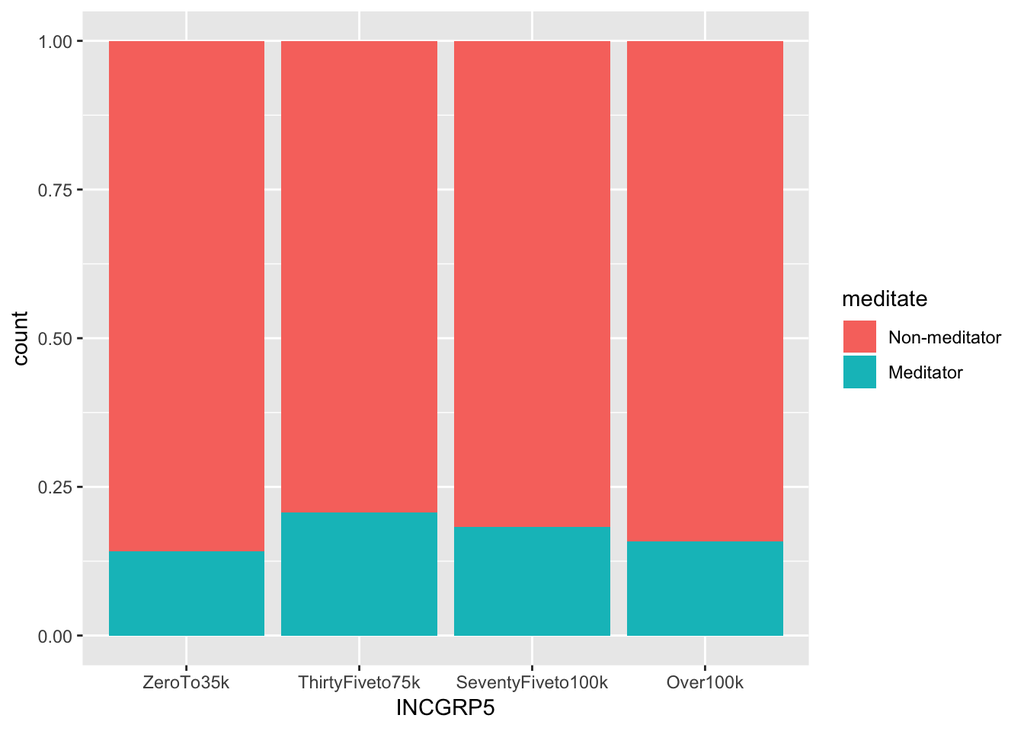

```r
#Generate a graph of the income of the two groups. Then perform an ordered logistic regression.
ggplot(data=subset(nhismerged,!is.na(INCGRP5)), aes(x=INCGRP5, fill=meditate)) +
    geom_bar(position="fill")
```

```r
incord <- polr(INCGRP5 ~ meditate, data = nhismerged, Hess=TRUE)
summary(incord)
```

```
## Call:
## polr(formula = INCGRP5 ~ meditate, data = nhismerged, Hess = TRUE)
##
## Coefficients:
##                    Value Std. Error t value
## meditateMeditator 0.2569    0.09601   2.676
##
## Intercepts:
##                                   Value   Std. Error t value
## ZeroTo35k|ThirtyFiveto75k          0.1824  0.0422     4.3182
## ThirtyFiveto75k|SeventyFiveto100k  1.5430  0.0532    29.0086
## SeventyFiveto100k|Over100k         2.1830  0.0654    33.3659
##
## Residual Deviance: 6052.233
## AIC: 6060.233
## (273 observations deleted due to missingness)
```

```r
ctable2 <- coef(summary(incord))
pincord <- pnorm(abs(ctable2[, "t value"]), lower.tail = FALSE) * 2
ctable2 <- cbind(ctable2, "p value" = pincord)
ctable2
```

```
##                                       Value Std. Error   t value       p value
## meditateMeditator                 0.2568866 0.09601173  2.675575  7.460111e-03
## ZeroTo35k|ThirtyFiveto75k         0.1823527 0.04222865  4.318221  1.572916e-05
## ThirtyFiveto75k|SeventyFiveto100k 1.5429834 0.05319047 29.008644 5.119063e-185
## SeventyFiveto100k|Over100k        2.1829867 0.06542565 33.365916 4.281809e-244
```

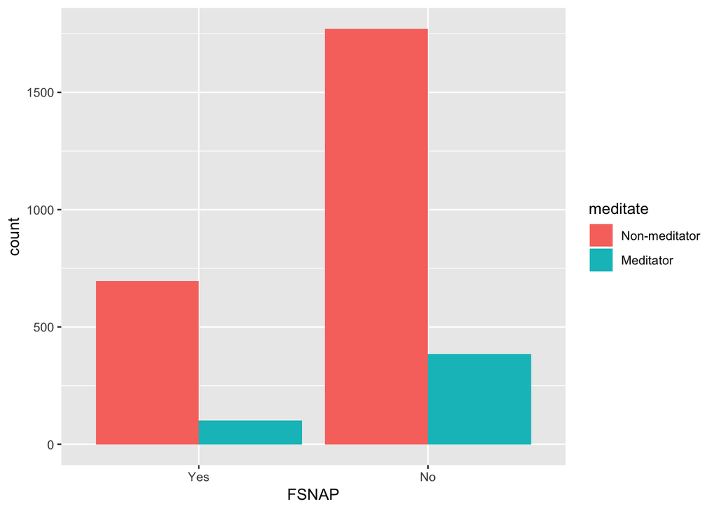

```r
#Generate a graph of the snap/foodstamp use of the two groups. Then perform a chi-squared test.
ggplot(data=subset(nhismerged, !is.na(FSNAP)), aes(x=FSNAP, fill=meditate)) +
    geom_bar(position="dodge")
```

```r
chisq.test(nhismerged$FSNAP,nhismerged$meditate)
```

```
##
##  Pearson's Chi-squared test with Yates' continuity correction
##
## data:  nhismerged$FSNAP and nhismerged$meditate
## X-squared = 10.74, df = 1, p-value = 0.001049
```

I then wanted to explore how their health differs. Here I look at how smoking status, exercise activity, and depression affects the groups differently. I also wanted to look at health behavior and saw how they utilize naturopathy differently.

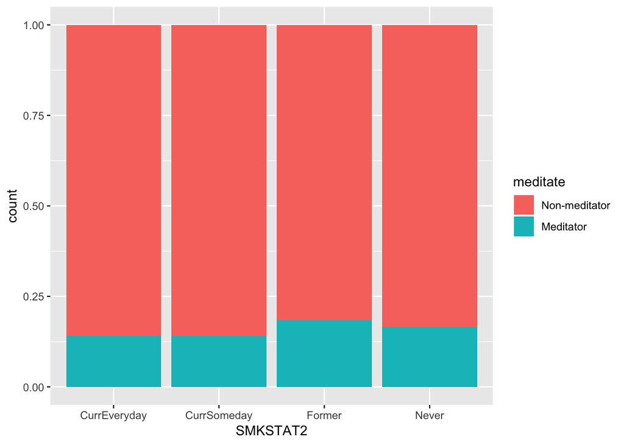

```r
#Generate a graph of the smoking use of the two groups. Then perform an ordered logistic regression.
ggplot(data=subset(nhismerged,!is.na(SMKSTAT2)), aes(x=SMKSTAT2, fill=meditate)) +
    geom_bar(position="fill")
```

```r
smkord <- polr(SMKSTAT2 ~ meditate, data = nhismerged, Hess=TRUE)
summary(smkord)
```

```
## Call:
## polr(formula = SMKSTAT2 ~ meditate, data = nhismerged, Hess = TRUE)
##
## Coefficients:
##                     Value Std. Error t value
## meditateMeditator 0.06629     0.1049   0.632
##
## Intercepts:
##                          Value    Std. Error t value
## CurrEveryday|CurrSomeday  -2.0419   0.0604   -33.7845
## CurrSomeday|Former        -1.6298   0.0528   -30.8696
## Former|Never              -0.7522   0.0432   -17.4310
##
## Residual Deviance: 5561.832
## AIC: 5569.832
## (16 observations deleted due to missingness)
```

```r
ctable5 <- coef(summary(smkord))
psmkord <- pnorm(abs(ctable5[, "t value"]), lower.tail = FALSE) * 2
ctable5 <- cbind(ctable5, "p value" = psmkord)
ctable5
```

```
##                                Value Std. Error     t value       p value
## meditateMeditator         0.06628713 0.10489077   0.6319634  5.274108e-01
## CurrEveryday|CurrSomeday -2.04192752 0.06043981 -33.7844819 3.333412e-250
## CurrSomeday|Former       -1.62976311 0.05279505 -30.8696190 3.055626e-209
## Former|Never             -0.75219482 0.04315260 -17.4310448  4.796161e-68
```

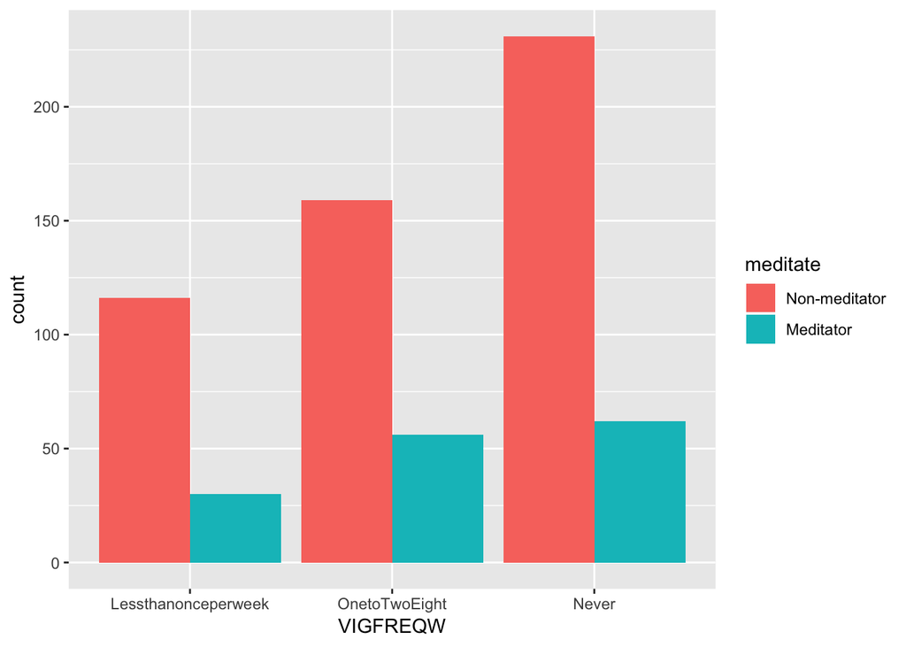

```r
#Generate a graph of the smoking use of the two groups. Then perform an ordered logistic regression.
ggplot(data=subset(nhismerged,!is.na(VIGFREQW)), aes(x=VIGFREQW, fill=meditate)) +
    geom_bar(position="dodge")
```

```r
vigord <- polr(VIGFREQW ~ meditate, data = nhismerged, Hess=TRUE)
summary(vigord)
```

```
## Call:
## polr(formula = VIGFREQW ~ meditate, data = nhismerged, Hess = TRUE)
##
## Coefficients:
##                      Value Std. Error t value
## meditateMeditator -0.04929     0.1719 -0.2868
##
## Intercepts:
##                                   Value    Std. Error t value
## Lessthanonceperweek|OnetoTwoEight  -1.2585   0.1024   -12.2884
## OnetoTwoEight|Never                 0.1972   0.0883     2.2326
##
## Residual Deviance: 1386.654
## AIC: 1392.654
## (2306 observations deleted due to missingness)
```

```r
ctable6 <- coef(summary(vigord))
pvigord <- pnorm(abs(ctable6[, "t value"]), lower.tail = FALSE) * 2
ctable6 <- cbind(ctable6, "p value" = pvigord)
ctable6
```

```
##                                        Value Std. Error     t value      p value
## meditateMeditator                 -0.0492864 0.17185192  -0.2867958 7.742687e-01
## Lessthanonceperweek|OnetoTwoEight -1.2585405 0.10241711 -12.2883813 1.045792e-34
## OnetoTwoEight|Never                0.1971804 0.08831876   2.2325993 2.557538e-02
```

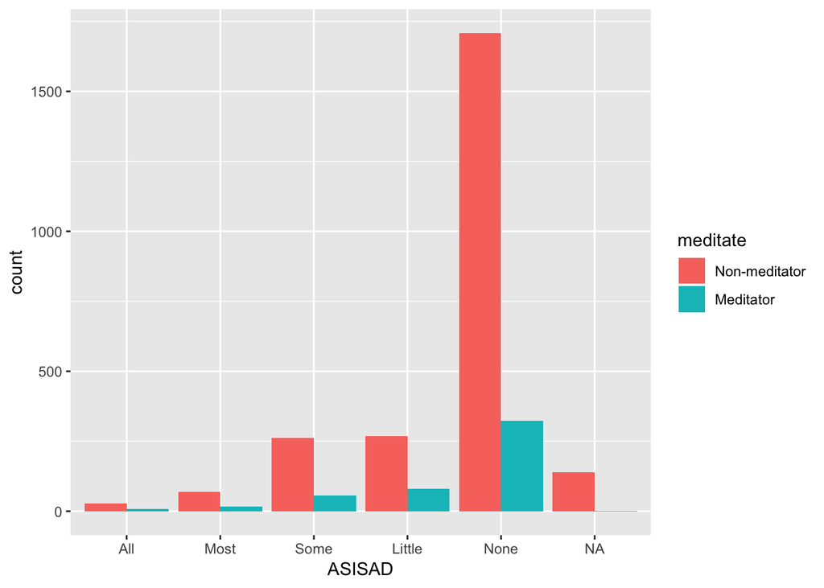

```r
#Generate a graph of the smoking use of the two groups. Then perform an ordered logistic regression.
ggplot(data=nhismerged, aes(x=ASISAD, fill=meditate)) +
    geom_bar(position="dodge")
```

```r
sadord <- polr(ASISAD ~ meditate, data = nhismerged, Hess=TRUE)
summary(sadord)
```

```
## Call:
## polr(formula = ASISAD ~ meditate, data = nhismerged, Hess = TRUE)
##
## Coefficients:
##                     Value Std. Error t value
## meditateMeditator -0.2689     0.1047  -2.569
##
## Intercepts:
##             Value    Std. Error t value
## All|Most     -4.4280   0.1714   -25.8307
## Most|Some    -3.1646   0.0957   -33.0802
## Some|Little  -1.7415   0.0560   -31.1066
## Little|None  -0.9967   0.0466   -21.3866
##
## Residual Deviance: 5076.759
## AIC: 5086.759
## (140 observations deleted due to missingness)
```

```r
ctable <- coef(summary(sadord))
psadord <- pnorm(abs(ctable[, "t value"]), lower.tail = FALSE) * 2
ctable <- cbind(ctable, "p value" = psadord)
ctable
```

```
##                        Value Std. Error    t value       p value
## meditateMeditator -0.2688944 0.10466456  -2.569107  1.019610e-02
## All|Most          -4.4280411 0.17142555 -25.830695 4.009851e-147
## Most|Some         -3.1646142 0.09566502 -33.080161 5.733071e-240
## Some|Little       -1.7415006 0.05598491 -31.106605 1.960795e-212
## Little|None       -0.9966610 0.04660223 -21.386553 1.782542e-101
```

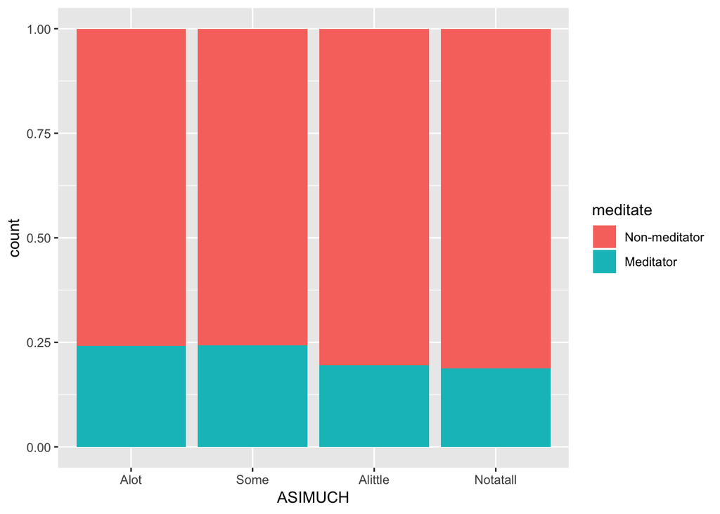

```r
#Generate a graph of the smoking use of the two groups. Then perform an ordered logistic regression.
ggplot(data=subset(nhismerged,!is.na(ASIMUCH)), aes(x=ASIMUCH, fill=meditate)) +
    geom_bar(position="fill")
```

```r
globalord <- polr(ASIMUCH ~ meditate, data = nhismerged, Hess=TRUE)
summary(globalord)
```

```
## Call:
## polr(formula = ASIMUCH ~ meditate, data = nhismerged, Hess = TRUE)
##
## Coefficients:
##                     Value Std. Error t value
## meditateMeditator -0.2419      0.143  -1.692
##
## Intercepts:
##                  Value    Std. Error t value
## Alot|Some         -2.1131   0.1056   -20.0041
## Some|Alittle      -0.8181   0.0750   -10.9085
## Alittle|Notatall   0.2775   0.0706     3.9302
##
## Residual Deviance: 2544.97
## AIC: 2552.97
## (1970 observations deleted due to missingness)
```

```r
ctable4 <- coef(summary(globalord))
globalord <- pnorm(abs(ctable4[, "t value"]), lower.tail = FALSE) * 2
ctable4 <- cbind(ctable4, "p value" = globalord)
ctable4
```

```
##                        Value Std. Error    t value      p value
## meditateMeditator -0.2418945 0.14297231  -1.691898 9.066549e-02
## Alot|Some         -2.1131086 0.10563404 -20.004050 5.077662e-89
## Some|Alittle      -0.8181465 0.07500060 -10.908533 1.049364e-27
## Alittle|Notatall   0.2774704 0.07059962   3.930196 8.487652e-05
```

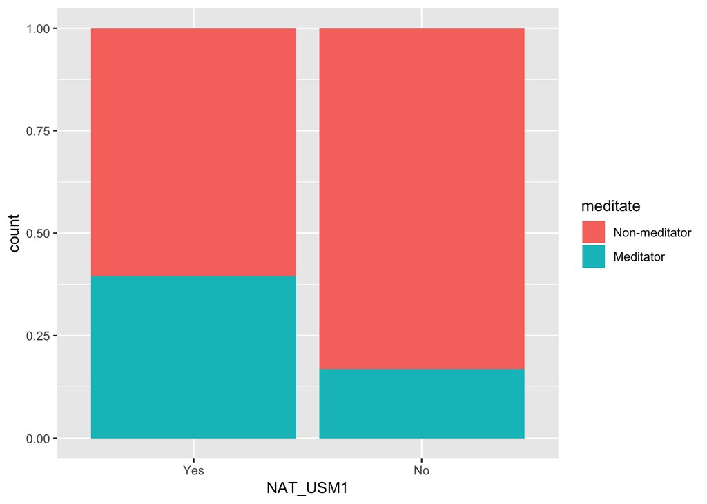

```r
#Generate a graph of the smoking use of the two groups. Then perform an ordered logistic regression.
ggplot(data=subset(nhismerged, !is.na(NAT_USM1)), aes(x=NAT_USM1, fill=meditate)) +
    geom_bar(position="fill")
```

```r
chisq.test(nhismerged$NAT_USM1,nhismerged$meditate)
```

```
##
##  Pearson's Chi-squared test with Yates' continuity correction
##
## data:  nhismerged$NAT_USM1 and nhismerged$meditate
## X-squared = 11.983, df = 1, p-value = 0.0005369
```

In conclusion it doesn’t seem like in most aspects there is much difference between the groups. There does seem to be difference in utilization of naturopathy. It may be that they aren’t all that much healthier but may navigate the healthcare system differently.

In the future I would have loved to explore the specific meditation styles (mantra, spirituality, and mindfulness) to see if specific styles may have had an affect. I also would have loved to explore the idea of healthcare utilization further.